# 6 — Sensing and State Estimation

What the robot can actually know · SOC4180 Robot and AI

Hong Jeong

## Six weeks, zero sensors

Both controllers we have built are **open loop**. The LIPM walker follows a plan computed before it started moving. The CPG oscillates on a timer. Neither has ever looked at the robot.

That is why the CPG fell every time, and why the LIPM walker drifts sideways with nothing to pull it back.

Today the robot finds out about itself. This is the week that makes feedback possible — and the observation vector we build here is exactly what a learned policy will consume from Week 8 onward.

## The cheating we have been doing

In simulation you can ask the robot anything:

```
pelvis position in the world : [0.   0.   0.79]
orientation quaternion       : [1. 0. 0. 0.]
```

**A real robot knows neither of these.** There is no sensor for “where am I in the room” and none for absolute attitude. Everything in `qpos[:7]` is *privileged* information the simulator happens to have.

Build a controller on it and it cannot leave the simulator.

## What the G1 actually has

```
  GYRO           dim=3  imu-torso-angular-velocity
  ACCELEROMETER  dim=3  imu-torso-linear-acceleration
  GYRO           dim=3  imu-pelvis-angular-velocity
  ACCELEROMETER  dim=3  imu-pelvis-linear-acceleration

  total sensordata: 12 numbers
```

**Two IMUs** — torso and pelvis — each a gyroscope plus an accelerometer. Twelve numbers per timestep, and that is the entire sensory world of this robot.

No cameras. No joint torque sensors. No foot contact switches. Joint *encoders* are implicit: a real robot reads its own joint angles, which is why using `qpos[7:]` is fair while using `qpos[:7]` is not.

## What an accelerometer really measures

Not acceleration. **Specific force** — the non-gravitational force per unit mass. A device sitting still on a table is being pushed *up* by the table:

```
at rest  : accel = [ 0.03 -0.    9.81]   |accel| = 9.810
in free fall: accel = [-0.  0.  0.]
```

Standing still it reads **9.81 upward**. In free fall it reads **zero** — nothing is pushing it. That is the whole reason an accelerometer is a *tilt* sensor: at rest, the direction it reports is “down”.

## Gravity is the only compass

Rotate the body and gravity moves in the body’s frame. That vector is the robot’s attitude reference:

```
gravity in the body frame (upright): [-0.001  0.    -1.   ]
roll, pitch from the accelerometer : [-0.003 -0.175] deg
```

Two things this gives you, and one it does not:

- **roll and pitch** — recoverable, because gravity is not aligned with either
- **yaw** — *not* recoverable. Spin about the vertical axis and gravity does not move. A gyroscope drifts; a magnetometer is unreliable indoors near motors

Locomotion policies therefore observe **gravity in the body frame** rather than absolute pose. It is the largest piece of attitude a real robot can honestly know.

## In simulation the sensors are perfect

```
two identical runs, identical sensordata: True
noise declared in the model: [0.0005 0.01  ]  (gyro, accel)
```

The MJCF declares noise magnitudes, but this MuJoCo build applies none — readings are **exactly** deterministic.

That is convenient and dishonest. A real gyroscope has a slowly wandering bias; a real accelerometer is noisy and lags. **We will inject those ourselves**, because an estimator tested on perfect sensors teaches nothing.

## Watch the assumption break

Tilt-from-gravity assumes the accelerometer sees *only* gravity. Walk, and it does not:

```
|accel| during the walk : 3.36 .. 19.34 m/s^2
                          (it would be 9.81 if only gravity acted)
true roll  : -6.11 .. +4.57 deg
```

The accelerometer swings from **3.4 to 19.3 m/s²**. Half of that is the robot, not the planet.

## Seeing the corruption

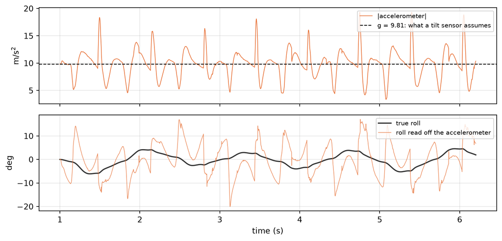

Every spike in the top plot is a footfall. Each one lands in the bottom plot as a tilt that never happened — the body did not roll twenty degrees, the sensor was kicked.

## Neither sensor is enough

```
accelerometer only : mean err  6.09 deg, worst 20.59 deg
gyroscope only, bias 0.000 rad/s : final err  0.13 deg
gyroscope only, bias 0.010 rad/s : final err  2.85 deg
```

**Complementary failure modes.** The accelerometer is wrong *now* but never gets worse. The gyroscope is right *now* but gets worse forever. A perfect gyro is near-exact — which is precisely why we injected a bias to see the real problem.

## Blend them

Trust the gyroscope over short intervals; let gravity correct it slowly.

$$\theta_k = \alpha\,(\theta_{k-1} + \omega_k \Delta t) \;+\; (1-\alpha)\,\theta_{\text{accel}}$$

```
  alpha = 0.9              mean err  5.65 deg,  final err  5.87 deg
  alpha = 0.98             mean err  3.52 deg,  final err  5.25 deg
  alpha = 0.995            mean err  1.46 deg,  final err  1.37 deg
  alpha = 1.0 (gyro only)  mean err  1.38 deg,  final err  2.86 deg
```

At $\alpha = 0.995$ the **final** error is 1.37 deg, against 2.85 deg for the drifting gyroscope and far worse for the accelerometer.

Read the two columns carefully: $\alpha = 1.0$ has a marginally *lower mean* error but twice the final error. That gap is drift, and drift only grows – which is why mean error is the wrong way to judge an estimator you intend to run for an hour.

## What $\alpha$ really sets

Write the update in the $z$-domain and it splits into two filters that sum to one:

$$\Theta = \underbrace{\frac{1-\alpha}{1-\alpha z^{-1}}}_{\text{low-pass on the accelerometer}}\;\Theta_{\text{accel}}
\;+\;
\underbrace{\frac{\alpha\,\Delta t}{1-\alpha z^{-1}}}_{\text{integrates the gyro, high-pass}}\;\Omega$$

The pole at $z = \alpha$ gives a time constant $\tau = -\Delta t / \ln\alpha \approx \alpha\,\Delta t / (1-\alpha)$: **how long the gyroscope is trusted before gravity has the last word**.

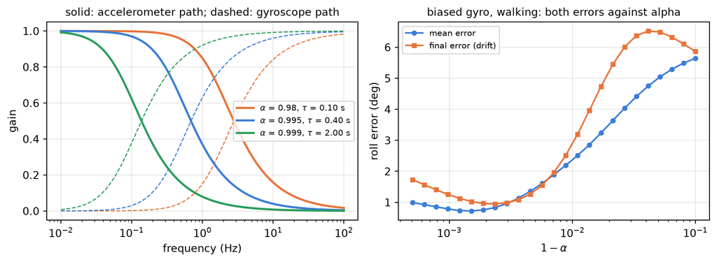

```
mean error is smallest at alpha = 0.9985 (tau = 1.32 s), final error at alpha = 0.9977
```

Both errors bottom out near $\alpha \approx 0.998$ — trust the gyroscope for about a second. Go **left** (trust it longer) and the bias leaks back in; go **right** (trust gravity sooner) and every footfall leaks in instead. Where the minimum sits depends on how bad the gyroscope is: a worse bias pushes it to the right, a rougher gait to the left. $\alpha$ is not a constant, it is a claim about your sensors.

## Seeing it

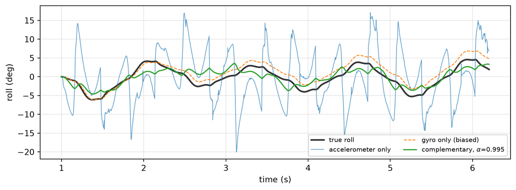

The dashed line walks away. The thin line is jagged. The filter is neither.

## Designing an observation

This is the week’s real product. What may a policy be given?

[output not shown]

```
observation vector: 64 numbers, every one measurable on hardware
```

## The observation, drawn to scale

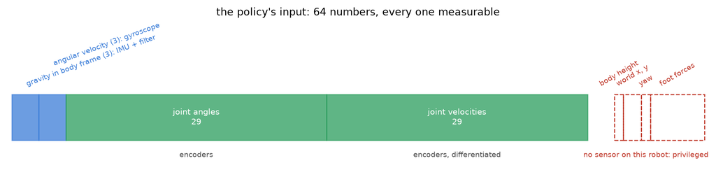

Sixty-four numbers in, twelve joint targets out. The dashed boxes are things the simulator knows and a real robot never will — which is exactly where the next slide’s trick comes in.

## Privileged information

Some quantities are unavailable at deployment but *known* during training — body height, contact forces, the terrain, the friction coefficient.

Throwing them away entirely is wasteful. The standard trick, which you will meet again in Week 10:

- the **policy** sees only what a real robot can measure
- the **value function** may see everything, since it is discarded after training

This is **asymmetric actor-critic**. The critic gets a clearer view of how good a state was; the actor stays deployable.

The discipline starts today: *what does the robot know, and how does it know it?*

## Lab class: on your laptop

```bash
uv run weeks/06-sensing/lab_imu.py
```

Three arrows hang from the torso IMU, each an estimate of *down* made from the IMU alone and drawn back in the world — so **right means vertical**. Orange is the accelerometer, cyan the integrated gyroscope, green the complementary filter `my_filter` (complete and explained: predict, correct, blend), white the truth.

| Step | Do | Right looks like |
| --- | --- | --- |
| 1 | ctrl-drag the standing robot | orange swings during the push and is right after; green barely moves |
| 2 | `N` (gyro bias + accel noise), `ENTER` twice | cyan leans further every time: drift, named |
| 3 | break `my_filter`: α = 1, then α = 0 | green becomes cyan, then orange |
| 4 | `W` to walk, then `[` `]` to sweep α | 7.8° / 3.4° / 1.8° mean error at α = 0.995; the trade named |
| 5 | `SITE = "pelvis"` | its accelerometer worse, its gyro better; an explanation either way |

## Lab class: `imu.py`, three estimators scored

```bash
uv run weeks/06-sensing/imu.py --walk --noise
uv run weeks/06-sensing/imu.py --walk --noise --sweep --no-viewer
```

```
error over the run (degrees):        mean    final
   accelerometer only         7.79    10.46
   gyroscope only             3.43     6.58
   complementary filter       1.79     2.06         (alpha 0.995)
sweep:   alpha  tau (s)    mean   final
        0.9900     0.20    2.77    3.25
        0.9980     1.00    1.15    0.36
        0.9990     2.00    1.53    1.24
        1.0000      inf    3.43    6.58
```

| Step | Does | Calls |
| --- | --- | --- |
| 1 | the IMU: `nsensor = 4` is two gyro + accelerometer pairs | `read_imu`, `sensordata` |
| 2 | `tilt_from_accel`, `integrate_gyro`, `complementary` | numpy only |
| 3 | the loop, scored against `site_xmat` | `mj_step` |
| 6 | replay with arrows | `launch_viewer(passive=True)`, `mju_quatZ2Vec` |

## Exercises

1. **Noise, properly.** Add Gaussian noise to the accelerometer at the magnitude the MJCF declares (0.01). How much does the accelerometer-only estimate degrade, and how much does the filter?
2. **Sweep $\alpha$.** Plot mean and final error against $\alpha$ from 0.9 to 1.0. Where is the optimum, and how sharp is it?
3. **Latency.** Delay the IMU by 20 ms before filtering. Which estimator suffers most, and does a different $\alpha$ compensate?
4. **The second IMU.** The pelvis IMU has been ignored all lecture. Does averaging both improve the estimate? Explain the result either way.
5. **Yaw.** Try to estimate yaw from these sensors. Show where it fails, and say what hardware would fix it.
6. **Close the loop.** Feed the estimated roll back into the Week 4 walker as a small lateral correction. Does it reduce the sideways drift?

## Next week

**07 — from control to learning.** We stop deriving controllers and start specifying *problems*: states, actions, rewards, and episodes. The observation vector built today becomes the input to a policy, and the walker you wrote by hand becomes the baseline it has to beat.